# Spatial pattern analyses of disease incidence data:

Daniel Heck, Kaique Alves, and Sarah Pethybridge

1/18/2022

# 1 Packages

```r
# install.packages("epiphy")  # Install the package in your computer
# install.packages("tidyverse")
library(epiphy) # Load the package in R environment
library(tidyverse)
```

# 2 Data

*citrus_ctc* datasets contains information about the **incidence** of citrus tristeza virus (CTV) disease of three orchards in eastern Spain for consecutive years.

We will be working with one field named **IVI3and4**.

```r
iv3 <- citrus_ctv$IVI3and4
iv3
```

| x | y | t | i | n |
| --- | --- | --- | --- | --- |
| 1 | 1 | 1991 | 1 | 1 |
| 2 | 1 | 1991 | 0 | 1 |
| 3 | 1 | 1991 | 0 | 1 |
| 4 | 1 | 1991 | 0 | 1 |
| 5 | 1 | 1991 | 0 | 1 |
| 6 | 1 | 1991 | 0 | 1 |
| 7 | 1 | 1991 | 0 | 1 |
| 8 | 1 | 1991 | 0 | 1 |
| 9 | 1 | 1991 | 1 | 1 |
| 10 | 1 | 1991 | 0 | 1 |

[output cut: 854 more lines]

```r
str(iv3)
```

```
## 'data.frame':    864 obs. of  5 variables:
##  $ x: int  1 2 3 4 5 6 7 8 9 10 ...
##  $ y: int  1 1 1 1 1 1 1 1 1 1 ...
##  $ t: int  1991 1991 1991 1991 1991 1991 1991 1991 1991 1991 ...
##  $ i: int  1 0 0 0 0 0 0 0 1 0 ...
##  $ n: int  1 1 1 1 1 1 1 1 1 1 ...
```

Here, *x* and *y* correspond to the spatial coordinates of the sampling units distributed in a regular two-dimensional grid.

- *x* and *y* are the row (18) id and the within-row (12) sampling unit id, respectively.
- *t* variable stands for the assessment time or date.
- *i* variable corresponds to the number of recorded individuals (presence or absence of symptomatics plants) in each sampling unit.
- *n* is the total number of individuals in a sampling unit.

As in the raw CTV incidence data set, *n* = 1, means that each sampling unit contains only one plant and so *i* can only be equal to 0 (the plant is healthy) or 1 (the plant is diseased).

## 2.1 handling

```r
inc <- incidence(iv3)
inc
```

```
## # A mapped object: incidence class
## # dim: 2 space, 1 time, 2 obs
##   [x] [y]  [t] [i] [n]
##     x   y    t   i   n
## 1   1   1 1991   1   1
## 2   2   1 1991   0   1
## 3   3   1 1991   0   1
## 4   4   1 1991   0   1
## 5   5   1 1991   0   1
## 6   6   1 1991   0   1
## # ... with 858 more records (rows)
```

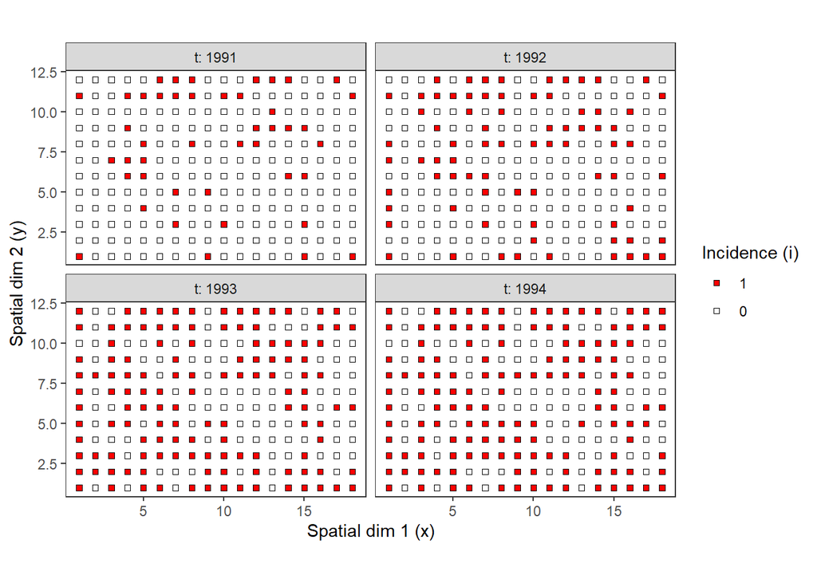

```r
plot(inc, tile = F)
```

The `clump` function is used to combine the individuals in larger sampling units.

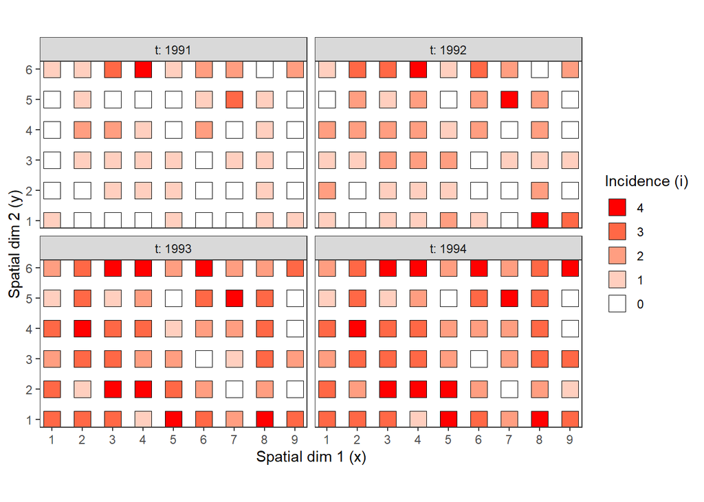

```r
inc4 <- clump(inc, unit_size = c(x = 2, y = 2))
plot(inc4, tile = F, size = 6)
```

```r
inc4_91 <- split(inc4, by = "t")[[1]]
inc4_94 <- split(inc4, by = "t")[[4]]
```

## 2.2 incidence

The incidence in the orchards can be calculated by:
$$\hat{y}=\sum_{i}y/nN$$

```r
(y_91 <- sum(inc4_91$data$i)/(inc4_91$data$n[1]*length(inc4_91$data$n)))
```

```
## [1] 0.2037037
```

```r
(y_94 <- sum(inc4_94$data$i)/(inc4_94$data$n[1]*length(inc4_94$data$n)))
```

```
## [1] 0.6296296
```

| Orchard | **y** |
| --- | --- |
| IV_1991 | 0.204 |
| IV_1994 | 0.629 |

# 3 Statistical methods

## 3.1 Dispersion index (*D*)

Fisher’s index of aggregation. In case of a count, this index corresponds to the ratio of the observed variance to the observed mean, and this is why this index is also known as the variance to mean ratio. For a binary variable, a similar index can be calculated using instead the ratio of the observed variance to the theoretical variance if data follow a binomial law (i.e. a reference distribution for a random pattern of individuals within sampling units).

$$H_0 = 1$$

```r
(inc4_91_idx <- agg_index(inc4_91))
```

```
## Fisher's index of dispersion:
## (Version for incidence data)
## 1.284
```

```r
chisq.test(inc4_91_idx)
```

```
##
##  Chi-squared test for (N - 1)*index following a chi-squared
##  distribution (df = N - 1)
##
## data:  inc4_91_idx
## X-squared = 68.042, df = 53, p-value = 0.07995
```

P-value = 0.079. The null hypothesis was not rejected (*P* > 0.05).

```r
(inc4_94_idx <- agg_index(inc4_94))
```

```
## Fisher's index of dispersion:
## (Version for incidence data)
## 1.486
```

```r
chisq.test(inc4_94_idx)
```

```
##
##  Chi-squared test for (N - 1)*index following a chi-squared
##  distribution (df = N - 1)
##
## data:  inc4_94_idx
## X-squared = 78.776, df = 53, p-value = 0.01232
```

P-value = 0.012. The null hypothesis was rejected (*P* < 0.05).

Table 3.1. Dispersion index estimated for an orchard assessed for disease incidence of Citrus Tristeza Virus in 1991 and 1994.

| Orchard | **D** | P-value | Result (aggregated or random) |
| --- | --- | --- | --- |
| IV_1991 | 1.28 | 0.079 |  |
| IV_1994 | 1.49 | 0.012 |  |

**Results interpretation:** The *IVI3and4* orchard assessed in 1991 can be considered as a **random** and the the same field assessed in 1994 can be considered **aggregated**.

## 3.2 Distribution fitting

Different distributions may be used depending on the kind of provided data. By default, the Poisson and negative binomial distributions are fitted to count data, whereas the binomial and beta-binomial distributions are used with incidence data. Either Randomness assumption (Poisson or binomial distributions) or aggregation assumption (negative binomial or beta-binomial) are made, and then, goodness-of-fit comparison of both distributions is made using a log-likelihood ratio (LRS) test statistic. The LRS has a $\chi^2$ distribution with one degree of freedom under the null hypothesis of no difference between the two log-likelihoods (i.e., the beta-binomial distribution does not fit the data better than the binomial).

```r
inc4_91_dist <- fit_two_distr(inc4_91)
summary(inc4_91_dist)
```

```
## Fitting of two distributions by maximum likelihood
## for 'incidence' data.
## Parameter estimates:
##
## (1) Binomial (random):
##      Estimate  Std.Err Z value    Pr(>z)
## prob 0.203704 0.027403  7.4336 1.057e-13 ***
## ---
## Signif. codes:  0 '***' 0.001 '**' 0.01 '*' 0.05 '.' 0.1 ' ' 1
##
## (2) Beta-binomial (aggregated):
##       Estimate  Std.Err Z value    Pr(>z)
## alpha 2.524706 2.333972  1.0817    0.2794
## beta  9.844670 9.230973  1.0665    0.2862
## prob  0.204109 0.030370  6.7208 1.807e-11 ***
## rho   0.074798 0.064493  1.1598    0.2461
## theta 0.080845 0.075343  1.0730    0.2833
## ---
## Signif. codes:  0 '***' 0.001 '**' 0.01 '*' 0.05 '.' 0.1 ' ' 1
```

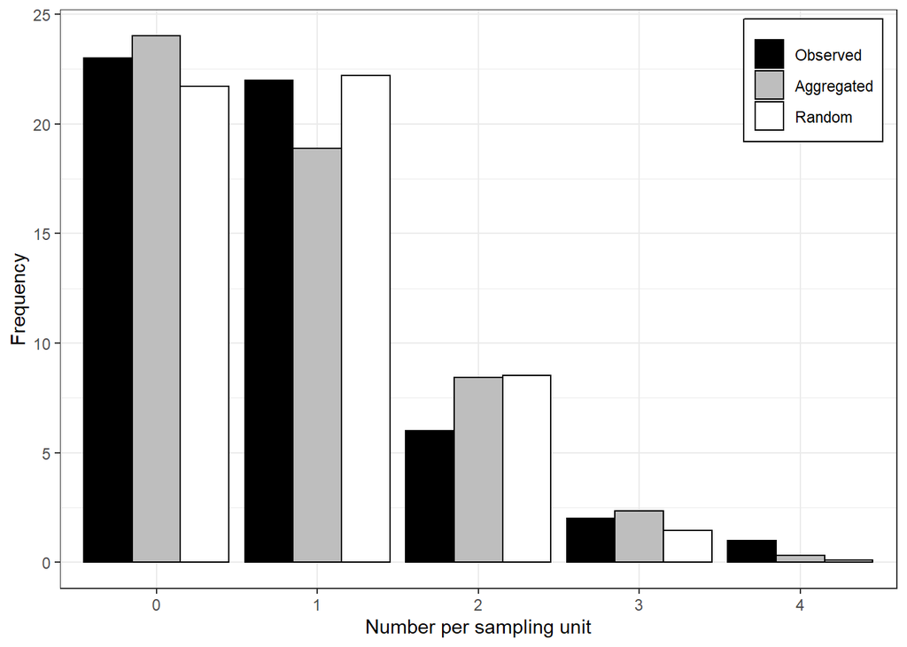

```r
dist_91 <- plot(inc4_91_dist)
```

```r
inc4_94_dist <- fit_two_distr(inc4_94)
summary(inc4_94_dist)
```

```
## Fitting of two distributions by maximum likelihood
## for 'incidence' data.
## Parameter estimates:
##
## (1) Binomial (random):
##      Estimate  Std.Err Z value    Pr(>z)
## prob 0.629630 0.032857  19.163 < 2.2e-16 ***
## ---
## Signif. codes:  0 '***' 0.001 '**' 0.01 '*' 0.05 '.' 0.1 ' ' 1
##
## (2) Beta-binomial (aggregated):
##       Estimate  Std.Err Z value  Pr(>z)
## alpha 3.665324 2.067954  1.7724 0.07632 .
## beta  2.174979 1.201353  1.8104 0.07023 .
## prob  0.627591 0.039516 15.8819 < 2e-16 ***
## rho   0.146192 0.069127  2.1148 0.03444 *
## theta 0.171224 0.094826  1.8057 0.07097 .
## ---
## Signif. codes:  0 '***' 0.001 '**' 0.01 '*' 0.05 '.' 0.1 ' ' 1
```

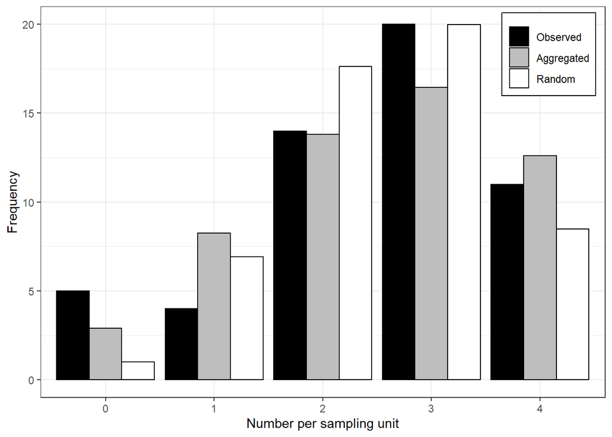

```r
dist_94 <- plot(inc4_94_dist)
```

To interpret the LRS test, we will retrieve the P-value by:

```r
(LRS_iv3_91 <- inc4_91_dist$llr$`Pr(>Chisq)`[2])
```

```
## [1] 0.1813656
```

```r
(LRS_iv3_94 <- inc4_94_dist$llr$`Pr(>Chisq)`[2])
```

```
## [1] 0.01411726
```

Table 3.2. Distribution fitting parameters estimated for an orchard assessed for disease incidence of Citrus Tristeza Virus in 1991 and 1994.

| Orchard | $\pi$ (binomial) | $p$ (beta) | $\theta$ (beta) | LRS (P-value) | Result (Binomial or beta-binomial) |
| --- | --- | --- | --- | --- | --- |
| IV_1991 | 0.203 | 0.204 | 0.080 | 0.181 |  |
| IV_1994 | 0.629 | 0.627 | 0.171 | 0.014 |  |

**Results interpretation:** The binomial distribution better fitted the *IVI3and4* orchard assessed in 1991, which suggest a **random** pattern. The beta-binomial distribution better fitted the orchard assessed in 1994 suggesting **aggregation**.

## 3.3 Binary power law

The power law describes the relationship between the observed variance of individuals within a data set ($s^2$) and the corresponding variance under the assumption of no aggregation. It can be expressed under its logarithmic form as:
$$log(s^2) = log(a) + b log(Y),$$
with:

$Y = p$ in the case of count data (Taylor’s power law).

$Y = p(1 - p)$ in the case of incidence data (binary power law).

$p$ corresponds to the mean proportion of recorded individuals in case of incidence data, and the absolute value in case of count data

The `power_law` function assesses the overall degree of heterogeneity in a collection of data sets at the sampling-unit scale.

### 3.3.1 Incidence dataset

For the sake of illustration, the incidence of CTV will be splitted into data sets of 9 sampling units each (3 rows × 3 sampling units × 1 recording date) before performing binary power law analysis on this data set in order to simulate a collection of different data sets.

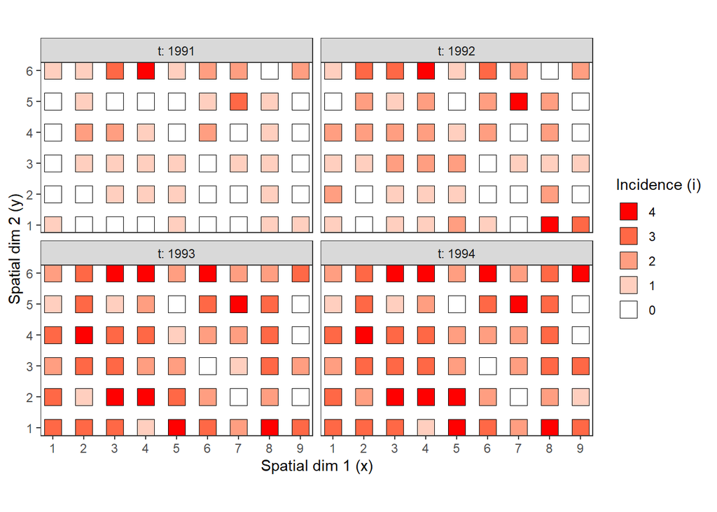

```r
plot(inc4, tile = F, size=6)
```

```r
inc9_spl <- split(inc4, unit_size = c(x = 3, y = 3))
inc_bpl <- power_law(inc9_spl)
summary(inc_bpl)
```

```
##
## Call:
## power_law(data = inc9_spl)
##
## Residuals:
##      Min       1Q   Median       3Q      Max
## -1.01158 -0.12330  0.07665  0.36163  0.46479
##
## Coefficients:
##                           Estimate Std. Error t value Pr(>|t|)
## (Intercept): log_base(Ar)   4.1067     0.9614   4.271 0.000311 ***
## log(x): b                   2.3011     0.3228   7.128 3.79e-07 ***
## Ai                         60.7487    58.4066   1.040 0.309590
## ai                          2.5012     1.2926   1.935 0.065946 .
## AI                          1.6477     0.1676   9.833 1.64e-09 ***
## aI                         40.0193    20.6815   1.935 0.065946 .
## ---
## Signif. codes:  0 '***' 0.001 '**' 0.01 '*' 0.05 '.' 0.1 ' ' 1
##
## Residual standard error: 0.3909 on 22 degrees of freedom
## Multiple R-squared:  0.6978, Adjusted R-squared:  0.6841
## F-statistic: 50.81 on 1 and 22 DF,  p-value: 3.795e-07
```

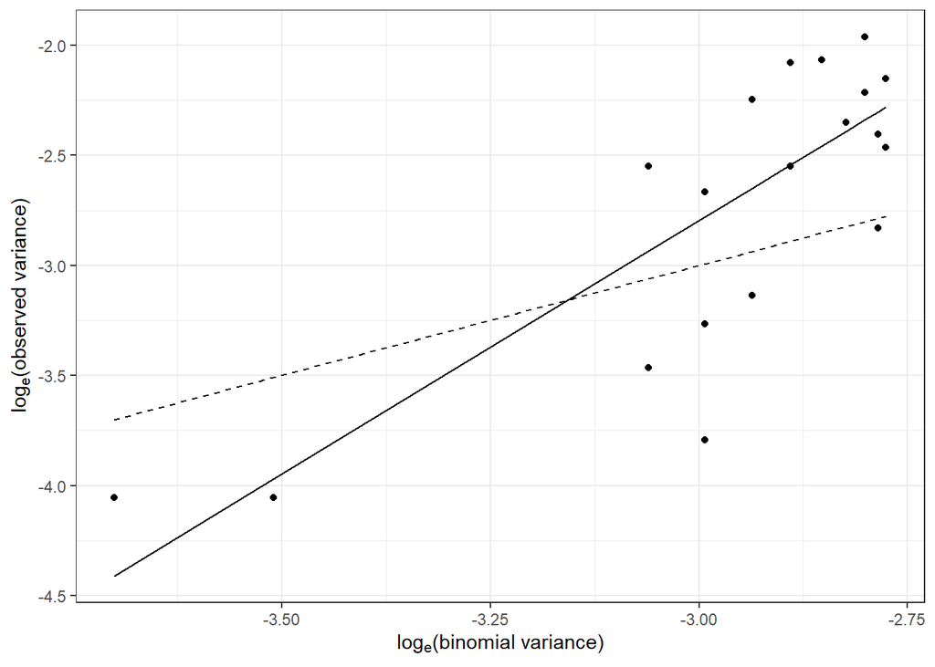

```r
plot(inc_bpl)
```

Table 3.3. Binary power law parameters estimated for an orchard assessed for disease incidence of Citrus Tristeza Virus from 1991 to 1994.

| Orchard | log(**A**) | **b** | Result |
| --- | --- | --- | --- |
| IVI3and4 | 4.106 | 2.301 |  |

### 3.3.2 Count dataset

A sampling unit was made of a pitfall to collect arthropods in a field of organic winter wheat, near Wimborne, Dorset, UK in 1996. The sampling units were located on a 9 x 7 rectangular grid at intervals of 30 m. There were six sampling dates.

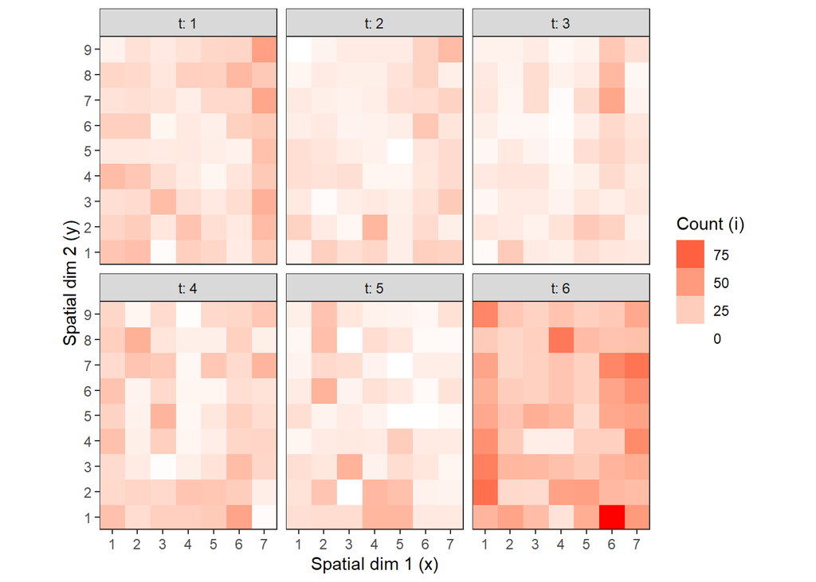

```r
art <- count_data(arthropods)
tpl <- plot(art)
```

```r
count_art <- split(art, unit_size = c(x = 7, y = 3))
(count_plaw <- power_law(count_art))
```

```
## Taylor's Power Law:
## Power law analysis for 'count' data.
##
## Coefficients:
## (Intercept)      log(x)
##    0.913264    1.280608
```

```r
summary(count_plaw)
```

```
##
## Call:
## power_law(data = count_art)
##
## Residuals:
##     Min      1Q  Median      3Q     Max
## -0.4530 -0.1067 -0.0419  0.1444  0.5676
##
## Coefficients:
##                           Estimate Std. Error t value Pr(>|t|)
## (Intercept): log_base(Ar)   0.9133     0.4864   1.878   0.0788 .
## log(x): b                   1.2806     0.1702   7.523 1.22e-06 ***
## ---
## Signif. codes:  0 '***' 0.001 '**' 0.01 '*' 0.05 '.' 0.1 ' ' 1
##
## Residual standard error: 0.2973 on 16 degrees of freedom
## Multiple R-squared:  0.7796, Adjusted R-squared:  0.7658
## F-statistic:  56.6 on 1 and 16 DF,  p-value: 1.22e-06
```

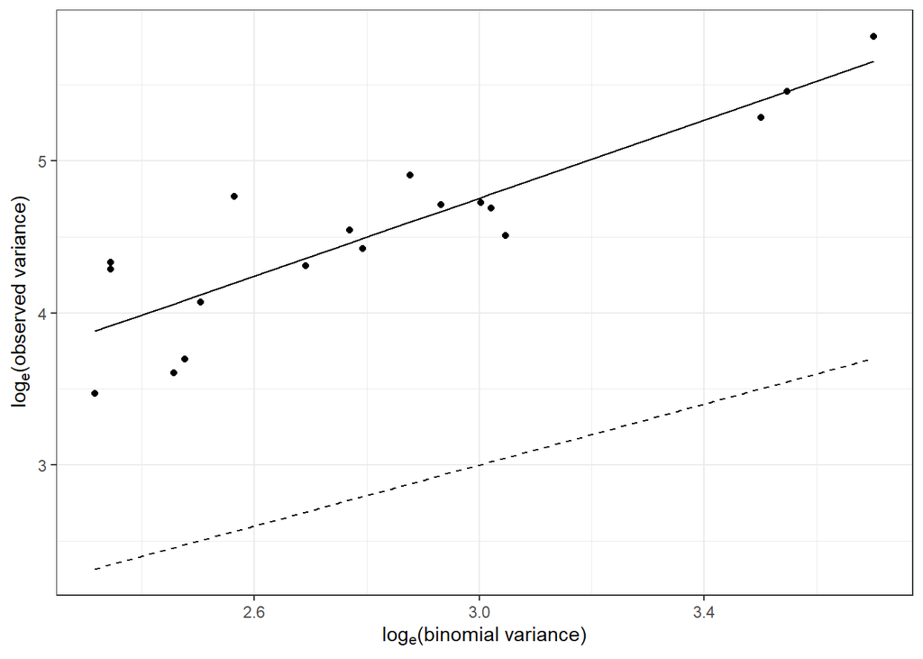

```r
plot(count_plaw)
```

## 3.4 SADIE

### 3.4.1 Count Data

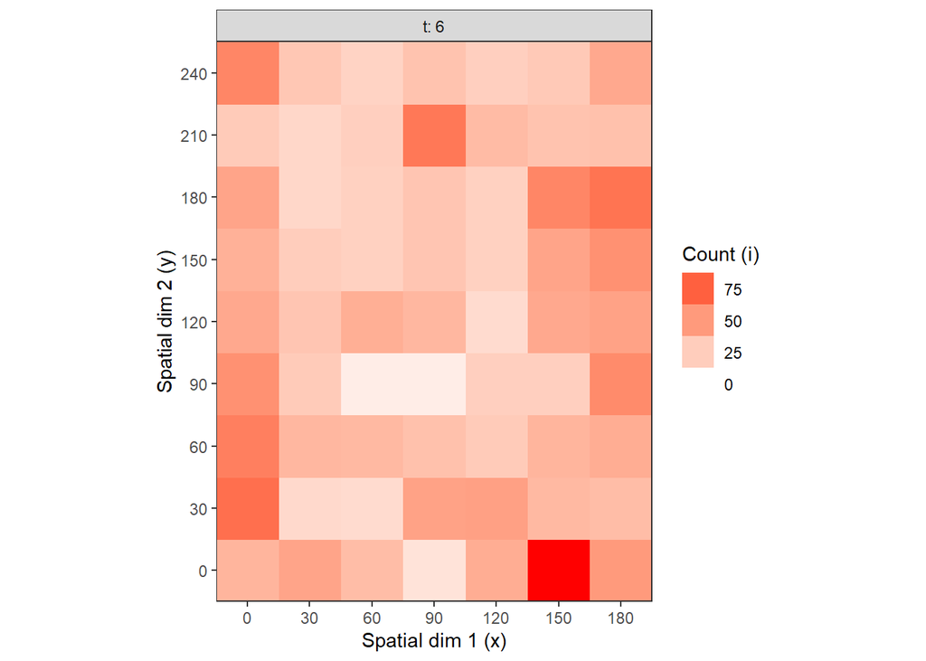

```r
arthropods_t6 <- arthropods %>%
  filter(t == 6)

cou_t3 <- epiphy::count(arthropods_t6, epiphy::mapping(x = xm, y = ym, t = t, i = i))

plot(cou_t3)
```

### 3.4.2 SADIE

```r
res <- sadie(cou_t3, nperm = 1000)
```

```
## Computation of Perry's indices:
```

```r
summary(res)
```

```
##
## Call:
## sadie.count(data = cou_t3, nperm = 1000)
##
## First 6 rows of clustering indices:
##     x y  i cost_flows      idx_P idx_LMX prob
## 1   0 0 37   42.42641  1.0585154      NA   NA
## 2  30 0 45   38.04715  1.0118800      NA   NA
## 3  60 0 33  -30.00000 -0.8003350      NA   NA
## 4  90 0 14  -53.39311 -1.0925181      NA   NA
## 5 120 0 41   30.00000  0.8027992      NA   NA
## 6 150 0 96   84.62998  1.4034715      NA   NA
##
## Summary indices:
##                       overall    inflow  outflow
## Perry's index        1.163063 -1.283746 1.185023
## Li-Madden-Xu's index       NA        NA       NA
##
## Main outputs:
## Ia: 1.1482 (Pa = 0.149)
##
## 'Total cost': 1309.977
## Number of permutations: 1000
```

### 3.4.3 Ploting spatial pattern

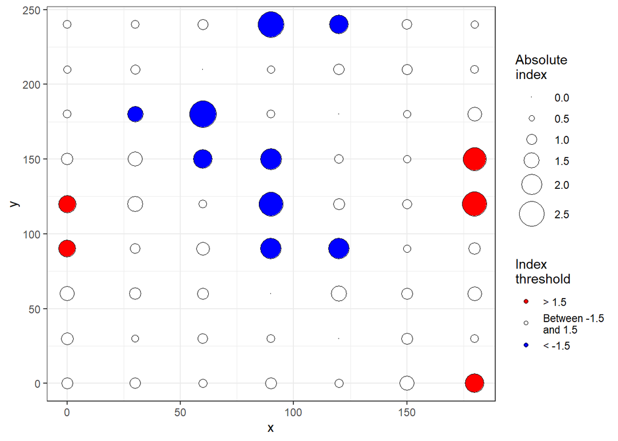

```r
plot(res)
```

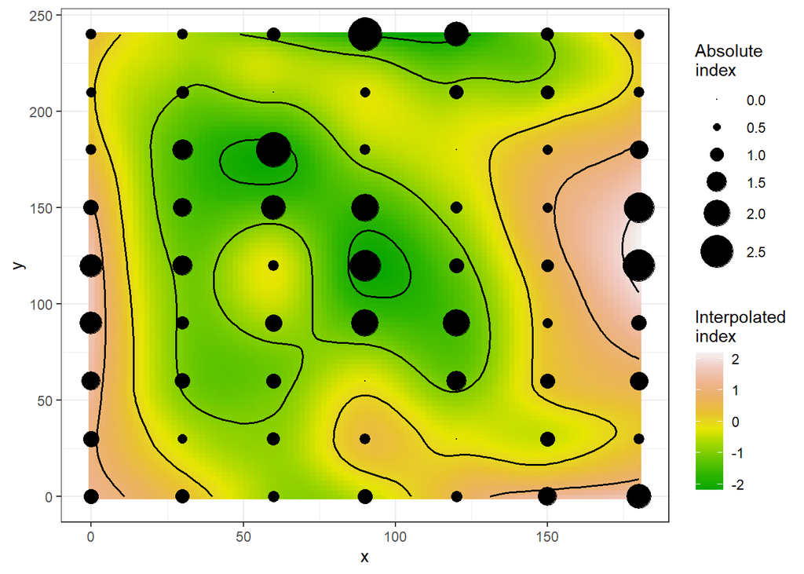

```r
plot(res, isoclines = TRUE)
```

# 4 Reference

https://chgigot.github.io/epiphy/articles/epiphy.html